# AIML_ML_Project_full_code_notebook_sindhuja

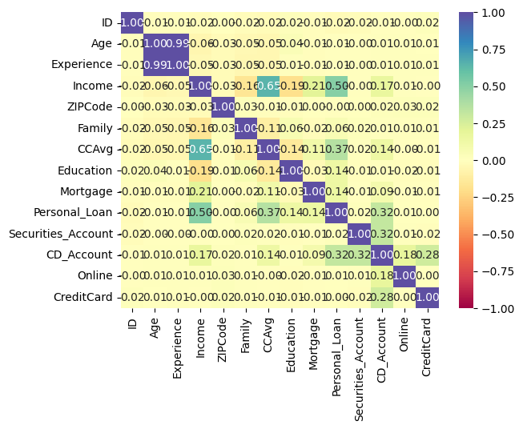

```python
corr = df.corr(numeric_only = True)

# plot the heatmap
sns.heatmap(corr,  annot=True, vmin=-1, vmax=1, fmt=".2f", cmap="Spectral")
```

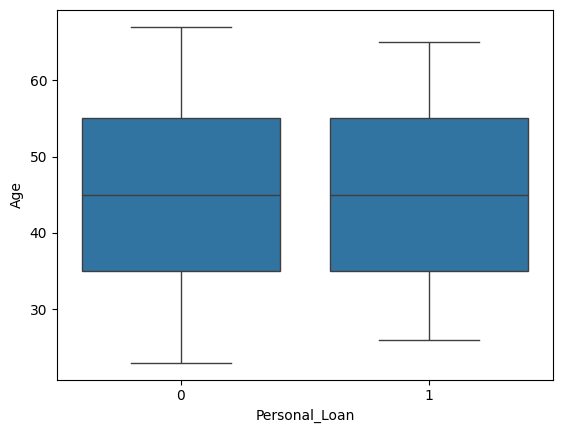

```python
sns.boxplot(x=df['Personal_Loan'], y=df['Age'])
```

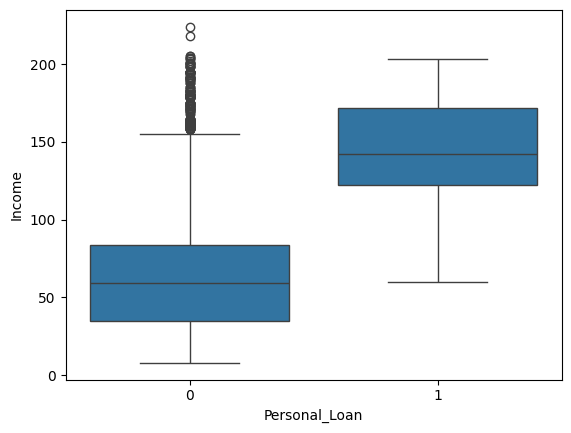

```python
sns.boxplot(x=df['Personal_Loan'], y=df['Income'])
```

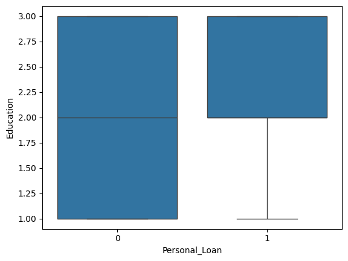

```python
sns.boxplot(x=df['Personal_Loan'], y=df['Education'])
```

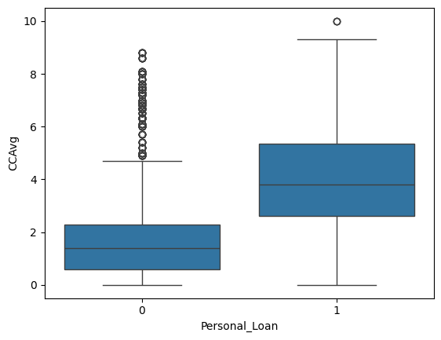

```python
sns.boxplot(x=df['Personal_Loan'], y=df['CCAvg'])
```

1. What is the distribution of mortgage attribute? Are there any noticeable patterns or outliers in the distribution?

mean = 56.50 median = 0

mean > median

Positively skewed

Most of the data points are concentrated in lower end 0- 100k

2. How many customers have credit cards?

Around 1400 customers has credit card out of 5000 customers

3. What are the attributes that have a strong correlation with the target attribute (personal loan)?

Target Attribute has strong correlation with below attributes in specific order

i) Income (0.50) ii) CCAvg (0.37) iii) CD_Account (0.32)

4. How does a customer's interest in purchasing a loan vary with their age?

From the boxplot, it is not showing any srong relationship between customer's interest in purchasing a loan with their age

5. How does a customer's interest in purchasing a loan vary with their education?

From the box plot, It shows customer's with education 2 & above (Graduate & Advanced) getting more personal loan

## Data Preprocessing

- Missing value treatment
- Feature engineering (if needed)
- Outlier detection and treatment (if needed)
- Preparing data for modeling
- Any other preprocessing steps (if needed)

```python
df.isnull().sum()
```

|  | 0 |
| --- | --- |
| ID | 0 |
| Age | 0 |
| Experience | 0 |
| Income | 0 |
| ZIPCode | 0 |
| Family | 0 |
| CCAvg | 0 |
| Education | 0 |
| Mortgage | 0 |
| Personal_Loan | 0 |
| Securities_Account | 0 |
| CD_Account | 0 |
| Online | 0 |
| CreditCard | 0 |

**dtype:** int64

There are no missing values in the dataset

```python
df.duplicated().sum()
```

```
np.int64(0)
```

There are no duplicate values in the dataset

```python
df.ID.nunique()
```

```
5000
```

This ID feature has unique data & we can drop it

```python
df=df.drop('ID',axis=1)
```

```python
# Assign input & output
X = df.drop('Personal_Loan', axis=1)
Y = df['Personal_Loan']

#split data in train & test (30 % for test & 70% for train)
from sklearn.model_selection import train_test_split
X_train, X_test, Y_train, Y_test = train_test_split(X, Y, test_size=0.3, random_state=1)
```

```python
print("Shape of Training set : ", X_train.shape)
print("Shape of test set : ", X_test.shape)
print("Percentage of classes in training set:")
print(Y_train.value_counts(normalize=True))
print("Percentage of classes in test set:")
print(Y_test.value_counts(normalize=True))
```

```
Shape of Training set :  (3500, 12)
Shape of test set :  (1500, 12)
Percentage of classes in training set:
Personal_Loan
0    0.905429
1    0.094571
Name: proportion, dtype: float64
Percentage of classes in test set:
Personal_Loan
0    0.900667
1    0.099333
Name: proportion, dtype: float64
```